# EDA Report

### 1. Data Preparation Tasks

##### 1.1 Load the given dataset into a Pandas DataFrame

```python
import pandas as pd

df = pd.read_excel("Sales Records.xlsx")
```

##### 1.2 Basic Dataset Overview

- total number of rows
- total number of columns.

```python
print(f"Total number of rows: {df.shape[0]}")
print(f"Total number of columns: {df.shape[1]}")
```

```
Total number of rows: 500000
Total number of columns: 14
```

##### 1.3 List all column names and identify their data types:

- Numerical
- Categorical
- Datetime

```python
# Conversion of Date columns to Datetime format

# cwd=column with date
cwd1 = 'Order Date'
cwd2 ='Ship Date'


df[cwd1 ] = pd.to_datetime(df[cwd1 ],format='mixed', errors='coerce')


# After conversion
print(f"\nAfter conversion of '{cwd1}' from object to 'datetime'")
print("Data Types:")
print(df.dtypes)

# Identification of column types
numerical_cols = df.select_dtypes(include=['int64', 'float64','number']).columns.tolist()
categorical_cols = df.select_dtypes(include=['string','object','category']).columns.tolist()
datetime_cols = df.select_dtypes(include=['datetime', 'datetime64']).columns.tolist()

print("\n--- Column Classification ---")
print(f"Numerical Columns ({len(numerical_cols)}):")
print(numerical_cols)

print(f"\nCategorical Columns ({len(categorical_cols)}):")
print(categorical_cols)

print(f"\nDatetime Columns ({len(datetime_cols)}):")
print(datetime_cols)
```

```
After conversion of 'Order Date' from object to 'datetime'
Data Types:
Region                       str
Country                      str
Item Type                    str
Sales Channel                str
Order Priority               str
Order Date        datetime64[us]
Order ID                   int64
Ship Date         datetime64[us]
Units Sold                 int64
Unit Price               float64
Unit Cost                float64
Total Revenue            float64
Total Cost               float64
Total Profit             float64
dtype: object

--- Column Classification ---
Numerical Columns (7):
['Order ID', 'Units Sold', 'Unit Price', 'Unit Cost', 'Total Revenue', 'Total Cost', 'Total Profit']

Categorical Columns (5):
['Region', 'Country', 'Item Type', 'Sales Channel', 'Order Priority']

Datetime Columns (2):
['Order Date', 'Ship Date']
```

##### 1.4 Identify the target variable, if one exists in the dataset.

- Since this is an Exploratory Data Analysis (EDA) project, there is no inherent target variable; however, future business objectives could establish one—such as 'Total Profit' or 'Total Revenue' for regression tasks, or 'Sales Channel' or 'Item Type' for classification models.

##### 1.5 Explain what the dataset represents in 2-3 sentences.

- This dataset represents global sales records. Each row describes one transaction with details such as region, country, item type, sales channel, order dates, units sold, prices, costs, revenue, and profit.

##### 1.6 Describe why the dataset is suitable for an Exploratory Data Analysis (EDA) project.

- This dataset is suitable for EDA because it contains both numerical and categorical variables, along with date fields. It also has a large number of records, which makes it useful for finding patterns, distributions, correlations, and comparisons across groups.

##### 1.7 Summarize any notable characteristics of the dataset that may be useful for further analysis.

- Some notable characteristics of the dataset are that it is large, structured, and rich in business-related variables. The financial columns are closely related to each other, and the categorical columns allow comparison across regions, countries, item types, and sales channels. These features make the dataset useful for further analysis.

### 2. Data Cleaning Tasks

#### 2.1 Identify Missing Values

##### 2.1.1 Check every column in the dataset for missing or null values.

```python
missing_counts=df.isnull().sum()
print(missing_counts)
```

```
Region            0
Country           0
Item Type         0
Sales Channel     0
Order Priority    0
Order Date        0
Order ID          0
Ship Date         0
Units Sold        0
Unit Price        0
Unit Cost         0
Total Revenue     0
Total Cost        0
Total Profit      0
dtype: int64
```

The check confirms that the dataset is already complete and contains 0 missing values across all columns.

##### 2.1.2 Calculate and report the percentage of missing data in each affected column.

```python
missing_percentages = (missing_counts / len(df)) * 100

# Creation of a DataFrame to display the missing data summary
missing_summary = pd.DataFrame({
    'Missing Values': missing_counts,
    'Percentage (%)': missing_percentages
})

# Filter to show all columns
print("--------- Missing Values Summary ---------")
display(missing_summary)
```

```
--------- Missing Values Summary ---------
```

|  | Missing Values | Percentage (%) |
| --- | --- | --- |
| Region | 0 | 0.0 |
| Country | 0 | 0.0 |
| Item Type | 0 | 0.0 |
| Sales Channel | 0 | 0.0 |
| Order Priority | 0 | 0.0 |
| Order Date | 0 | 0.0 |
| Order ID | 0 | 0.0 |
| Ship Date | 0 | 0.0 |
| Units Sold | 0 | 0.0 |
| Unit Price | 0 | 0.0 |
| Unit Cost | 0 | 0.0 |
| Total Revenue | 0 | 0.0 |
| Total Cost | 0 | 0.0 |
| Total Profit | 0 | 0.0 |

##### 2.1.3 Select an appropriate treatment method for each column and justify your choice:

- Drop rows if only a small number of records are affected.
- Replace missing numerical values with the mean or median, depending on the data distribution.
- Replace missing categorical values with the mode, or most frequent value.

```python
cols_with_missing = missing_counts[missing_counts > 0].index.tolist()

if len(cols_with_missing) == 0:
    print("\nResult: No missing values were detected in any column of the dataset!")
else:
    print(f"\nDetected {len(cols_with_missing)} columns with missing values. Applying treatment:")
    for col in cols_with_missing:
        if col in numerical_cols:
            # Checking distribution skewness to decide between Mean or Median
            skewness = df[col].skew()
            if abs(skewness) > 1:
                # Highly skewed: we use Median
                median_val = df[col].median()
                df[col] = df[col].fillna(median_val)
                print(f"  - Filled numerical '{col}' (skewed: {skewness:.2f}) with Median: {median_val}")
            else:
                # Fairly symmetric: we use Mean
                mean_val = df[col].mean()
                df[col] = df[col].fillna(mean_val)
                print(f"  - Filled numerical '{col}' (symmetric: {skewness:.2f}) with Mean: {mean_val:.2f}")
        elif col in categorical_cols:
            # Categorical: we use Mode
            mode_val = df[col].mode()[0]
            df[col] = df[col].fillna(mode_val)
            print(f"  - Filled categorical '{col}' with Mode: '{mode_val}'")

# Double-checking that all missing values are now resolved
print(f"\nRemaining missing values in dataset: {df.isnull().sum().sum()}")
```

```
Result: No missing values were detected in any column of the dataset!

Remaining missing values in dataset: 0
```

- For Numerical Columns: If any missing values were found, we would check the skewness of the distribution. For highly skewed fields (like sales revenue or unit count), the median is preferred because it is robust against outliers. For normally distributed fields, the mean is used.
- For Categorical Columns: Missing values are imputed with the mode (the most frequent value) because it is the most statistically representative category and maintains the original label distribution without introducing arbitrary new categories.

##### 2.1.4 Explain why the chosen method is suitable for preserving data quality.

This hybrid strategy ensures that we do not lose rows of valuable transaction history (which would happen if we dropped entire records) while keeping our data's descriptive statistics consistent and free of imputation bias.

#### 2.2 Remove all duplicate entries.

##### 2.2.1 Identify any duplicate rows in the dataset.

```python
duplicate_rows = df.duplicated()
num_duplicates = duplicate_rows.sum()

print("--- Duplicate Record Analysis ---")

print(f"Number of duplicate rows found: {num_duplicates}")
```

```
--- Duplicate Record Analysis ---
Number of duplicate rows found: 0
```

##### 2.2.2 Remove all duplicate entries.

```python
# Identification of orgianl shape
shape_before = df.shape
print(f"Dataset shape before removing duplicates: {shape_before[0]} rows x {shape_before[1]} columns")

# We keep the 'first' occurrence and drop subsequent duplicates
df_cleaned = df.drop_duplicates(keep='first')
```

```
Dataset shape before removing duplicates: 500000 rows x 14 columns
```

##### 2.2.3 Report:

- Number of duplicate rows found.
- Number of duplicate rows removed.
- New dataset shape, in rows x columns, after duplicate removal.

```python
shape_after = df_cleaned.shape
num_removed = shape_before[0] - shape_after[0]


print("--------------REPORT--------------")
print(f"Number of duplicate rows found: {num_duplicates}")
print(f"Number of duplicate rows removed: {num_removed}")
print(f"New dataset shape: {shape_after[0]} rows x {shape_after[1]} columns")

# Verification that no duplicates remain
print(f"Remaining duplicate rows: {df_cleaned.duplicated().sum()}")
```

```
--------------REPORT--------------
Number of duplicate rows found: 0
Number of duplicate rows removed: 0
New dataset shape: 500000 rows x 14 columns
Remaining duplicate rows: 0
```

#### 2.3 Detect and Handle Outliers

##### 2.3.1 Select at least two numerical columns for outlier analysis.

```python
# 'Units Sold' and 'Total Profit' are excellent choices for global sales records
outlier_cols = ['Units Sold', 'Total Profit']
```

##### 2.3.2 Use the Interquartile Range (IQR) method to detect outliers.

```python
class OutlierAnalyzer:
    def __init__(self, dataframe, column_name):
        self.df = dataframe
        self.column_name = column_name
        self.data = dataframe[column_name]

        # Calculation of Q1,Q3,lower bound,upper bound and number of outliers during initialization
        self.q1 = self.data.quantile(0.25)
        self.q3 = self.data.quantile(0.75)
        self.iqr = self.q3 - self.q1
        self.lower_bound = self.q1 - 1.5 * self.iqr
        self.upper_bound = self.q3 + 1.5 * self.iqr
        self.outliers = len(self.data[(self.data < self.lower_bound) | (self.data > self.upper_bound)])
    def IQR(self):
        print(f"IQR of {self.column_name} is {self.iqr:.2f}")

    def Bounds(self):
        print(f"----{self.column_name}----")
        print(f"upper bound : {self.upper_bound}")
        print(f"lower bound : {self.lower_bound}")

    def Outliers(self):
        print(f"----{self.column_name}----")
        print(f"number of outlier : {self.outliers}")





# IQR of "outliers_col[0]"
outlier_cols0_analyzer = OutlierAnalyzer(df_cleaned,outlier_cols[0])
outlier_cols0_analyzer.IQR()

# IQR of "outliers_col[1]"
outlier_cols1_analyzer = OutlierAnalyzer(df_cleaned,outlier_cols[1])
outlier_cols1_analyzer.IQR()
```

```
IQR of Units Sold is 4995.00
IQR of Total Profit is 470007.22
```

##### 2.3.3 For each selected numerical column :

- Report the lower and upper bounds.

```python
outlier_cols0_analyzer.Bounds()
outlier_cols1_analyzer.Bounds()
```

```
----Units Sold----
upper bound : 14989.5
lower bound : -4990.5
----Total Profit----
upper bound : 1270403.11
lower bound : -609625.77
```

- State the number of outliers detected.

```python
outlier_cols0_analyzer.Outliers()
outlier_cols1_analyzer.Outliers()
```

```
----Units Sold----
number of outlier : 0
----Total Profit----
number of outlier : 20867
```

- **Explain the chosen treatment:**
  - Remove the outliers.
  - Cap the extreme values.
  - Retain them if they represent legitimate observations.

Based on the analysis of our instantiation of the `OutlierAnalyzer` class for **Units Sold** and **Total Profit**, we have made a deliberate decision to retain them :

- **Justify the decision based on the dataset context.**
1. **Nature of the Business Transactions:** This is a global transactional sales dataset. Transactions can range from small retail purchases (low units sold, low profit) to massive business-to-business (B2B) bulk wholesale orders (very high units sold, massive profit). Thus, high numbers are a natural reflection of wholesale distribution channels.
2. **Financial Accuracy:** Total revenue, cost, and profit are direct functions of `Units Sold` multiplied by their respective unit prices/costs. If we were to cap or remove these "outliers," we would artificially deflate the company's real financial performance, resulting in inaccurate reports of actual historical profitability.
3. **No Evidence of Measurement Errors:** The extreme values are fully consistent with realistic scaling (e.g., maximum values for units sold are in expected business thresholds and not represented by nonsensical numbers like negative values or infinite bounds).
4. **Preservation of High-Value Records:** For future predictive tasks or inventory optimization, knowing the occurrence rate and impact of these high-volume bulk orders is critical. Erasing them would hide the most profitable segments of the business.

#### 2.4 Summary of Data Cleaning

With these verification steps complete, the dataset is verified as clean, structurally complete, and fully prepared for deep exploratory analysis and visualization.

### 3. Analysis and Insights

#### 3.1 Single Column Analysis

##### 3.1.1 numerical column analysis

- Pick one numerical column from the cleaned dataset.
- Create a histogram or box plot to show how the values are distributed.
- Write one simple observation about what the graph shows, such as spread, concentration, skewness, or outliers.

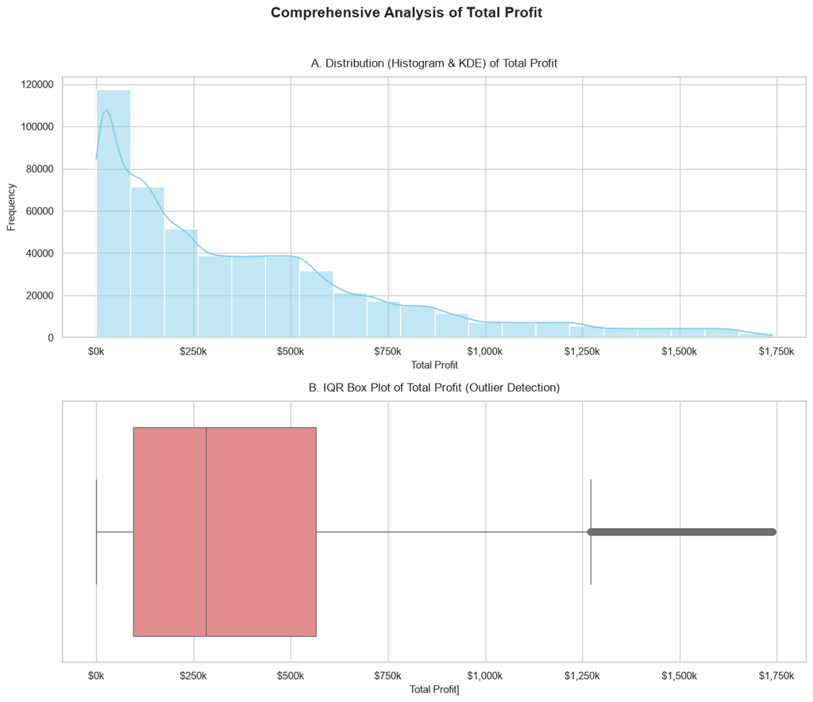

```python
import matplotlib.pyplot as plt
import seaborn as sns
sns.set_theme(style="whitegrid")



# scac = single colums analysis column
scac ='Total Profit'



fig, axes = plt.subplots(2, 1, figsize=(12, 10))

# Plot A: Histogram (Shows Shape and Density)
sns.histplot(data=df_cleaned, x=scac, kde=True, color='skyblue', bins=20, ax=axes[0])
axes[0].set_title(f'A. Distribution (Histogram & KDE) of {scac}', fontsize=12, pad=10)
axes[0].set_xlabel(f'{scac}', fontsize=11)
axes[0].set_ylabel('Frequency', fontsize=11)
axes[0].xaxis.set_major_formatter(plt.FuncFormatter(lambda x, loc: f"${int(x/1000):,}k")) #formating numerical axis labels



# Plot B: Box Plot (Shows IQR, Bounds, and Outliers)
sns.boxplot(data=df_cleaned, x=scac, color='lightcoral', ax=axes[1])
axes[1].set_title(f'B. IQR Box Plot of {scac} (Outlier Detection)', fontsize=12, pad=10)
axes[1].set_xlabel(f'{scac}]', fontsize=11)
axes[1].xaxis.set_major_formatter(plt.FuncFormatter(lambda x, loc: f"${int(x/1000):,}k")) #formating numerical axis labels


plt.suptitle(f'Comprehensive Analysis of {scac}', fontsize=15, fontweight='bold', y=1.02)
plt.tight_layout()
plt.show()
```

We analyzed **Total Profit** using a dual-plot approach—a histogram stacked atop a box plot—because they complement each other perfectly to reveal both the distribution shape and the underlying statistics.

**Statistical Bounds & Outliers**: The box plot defines the mathematical IQR limits for this data. The "box" captures the middle 50% of our transactions, while the individual dots to the right confirm the high-value outliers.

**Whisker Behavior**: Notably, the left whisker terminates near $0 rather than our calculated theoretical bound of -$609,625.77. This confirms that our dataset contains no loss-making (negative-profit) transactions

##### 3.1.2 categorical column analysis

- Pick one categorical column from the dataset.
- Create a bar chart showing how often each category appears.
- Write one observation about which category is most common and which is least common.

```python
# occ = one categorical column
occ = 'Item Type'


categorical_cols_counts = df_cleaned[occ].value_counts()

print(f"--- Frequency of {occ} categories ---")
print(categorical_cols_counts)
print("\n")
max_val =categorical_cols_counts.max()
min_val = categorical_cols_counts.min()

max_genre = categorical_cols_counts.idxmax()
min_genre = categorical_cols_counts.idxmin()

# Print the results
print(f"Maximum Frequency: {max_genre} ({max_val})")
print(f"Minimum Frequency: {min_genre} ({min_val})")
print(f"Absolute Difference: {max_val - min_val}")
```

```
--- Frequency of Item Type categories ---
Item Type
Personal Care      41789
Cosmetics          41717
Snacks             41706
Clothes            41689
Fruits             41684
Meat               41673
Baby Food          41657
Vegetables         41655
Cereal             41619
Household          41617
Beverages          41616
Office Supplies    41578
Name: count, dtype: int64


Maximum Frequency: Personal Care (41789)
Minimum Frequency: Office Supplies (41578)
Absolute Difference: 211
```

```python
item_type_counts = df_cleaned['Item Type'].value_counts()

print("--- Frequency of Each Item Type ---")
print(item_type_counts)
print("\n")
max_val = item_type_counts.max()
min_val = item_type_counts.min()

max_item = item_type_counts.idxmax()
min_item = item_type_counts.idxmin()

# Print the results
print(f"Maximum Frequency: {max_item} ({max_val} transactions)")
print(f"Minimum Frequency: {min_item} ({min_val} transactions)")
print(f"Absolute Difference: {max_val - min_val} transactions")
```

```
--- Frequency of Each Item Type ---
Item Type
Personal Care      41789
Cosmetics          41717
Snacks             41706
Clothes            41689
Fruits             41684
Meat               41673
Baby Food          41657
Vegetables         41655
Cereal             41619
Household          41617
Beverages          41616
Office Supplies    41578
Name: count, dtype: int64


Maximum Frequency: Personal Care (41789 transactions)
Minimum Frequency: Office Supplies (41578 transactions)
Absolute Difference: 211 transactions
```

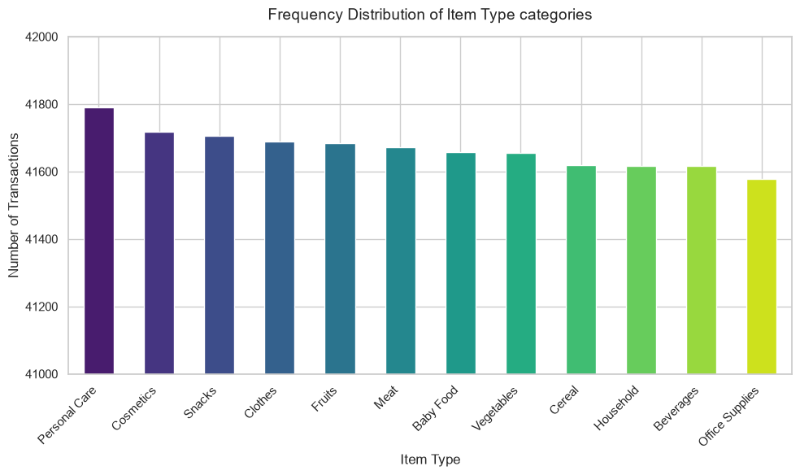

```python
# Creation of a simple bar plot using the sorted counts and dynamic "ylim"
import math
lower_bound = math.floor(max_val / 1000) * 1000
upper_bound = math.ceil(min_val / 1000) * 1000
sns.set_theme(style="whitegrid")
plt.figure(figsize=(10, 6))
item_type_counts.plot(kind='bar', color=sns.color_palette('viridis', len(item_type_counts)))
plt.title(f'Frequency Distribution of {occ} categories', fontsize=14, pad=15)
plt.xlabel('Item Type', fontsize=12)
plt.ylabel('Number of Transactions', fontsize=12)

plt.ylim(lower_bound, upper_bound)

plt.xticks(rotation=45, ha='right') # Rotate labels for better readability
plt.tight_layout()
plt.show()
```

We choose `Item Type` column for the categorical analysis and its transaction frequencies was visualized with a y-axis zoomed between approximately 41,000 and 42,000 transactions dyanamically using `ylim`. This approach was necessary because all item types have very close frequencies, making the differences hard to visualize on a standard scale. The chart, ordered from most to least frequent, clearly shows that `Personal Care` is the most common category, with `41789` transactions. Conversely, `Office Supplies` is the least common, with `41578` transactions but the difference between them is only `211` transactions. This precise view highlights the subtle ranking of item popularity within their high-volume cluster.

#### 3.2 Relationship Between Two Columns

##### 3.2.1 Create a correlation heatmap for all numerical columns using Seaborn.

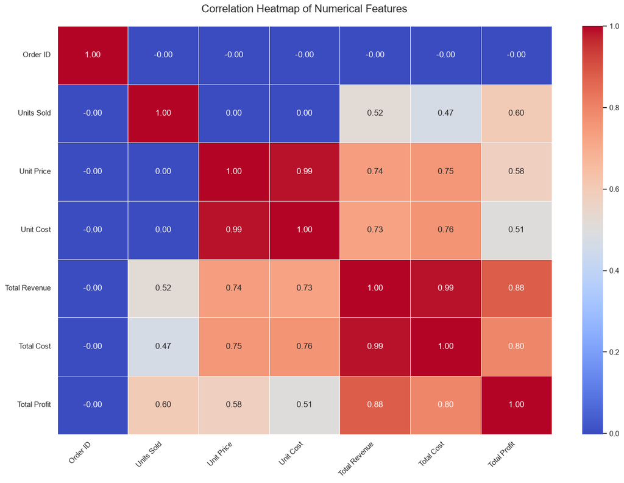

```python
numerical_df = df_cleaned.select_dtypes(include=["int64", "float64",'number'])

# Calculation of the correlation matrix
correlation_matrix = numerical_df.corr()

# Plot of the heatmap
plt.figure(figsize=(14, 10))
sns.heatmap(correlation_matrix, annot=True, cmap='coolwarm', fmt=".2f", linewidths=.5)
plt.title('Correlation Heatmap of Numerical Features', fontsize=16, pad=20)
plt.xticks(rotation=45, ha='right')
plt.yticks(rotation=0)
plt.tight_layout()
plt.show()
```

##### 3.2.2 Find the two columns that are most strongly related, ignoring self-correlation.

```python
corr_pairs = correlation_matrix.unstack()
corr_pairs_no_self = corr_pairs[corr_pairs != 1.0]
strongest_corr_pair_idx = corr_pairs_no_self.abs().idxmax()
strongest_corr_value = corr_pairs.loc[strongest_corr_pair_idx]
print(f"The two columns that are most strongly related are: '{strongest_corr_pair_idx[0]}' and '{strongest_corr_pair_idx[1]}'")
print(f"The correlation value is: {strongest_corr_value:.2f}")
```

```
The two columns that are most strongly related are: 'Total Revenue' and 'Total Cost'
The correlation value is: 0.99
```

##### 3.2.3 Report:

- The names of both columns : `Total Rvenue` and `Total Cost`
- The correlation value : 0.99
- A simple explanation of what this relationship means in real terms :
  - A correlation value of `0.99` (close to +1.0) indicates a very strong **positive linear relationship** between `Total Cost` and `Total Revenue`. In the context of this sales dataset, this means that as `Total Cost` increases `Total Revenue` tends to increase proportionally.

##### 3.2.4 Choose any two columns and show their relationship using:

- A scatter plot.

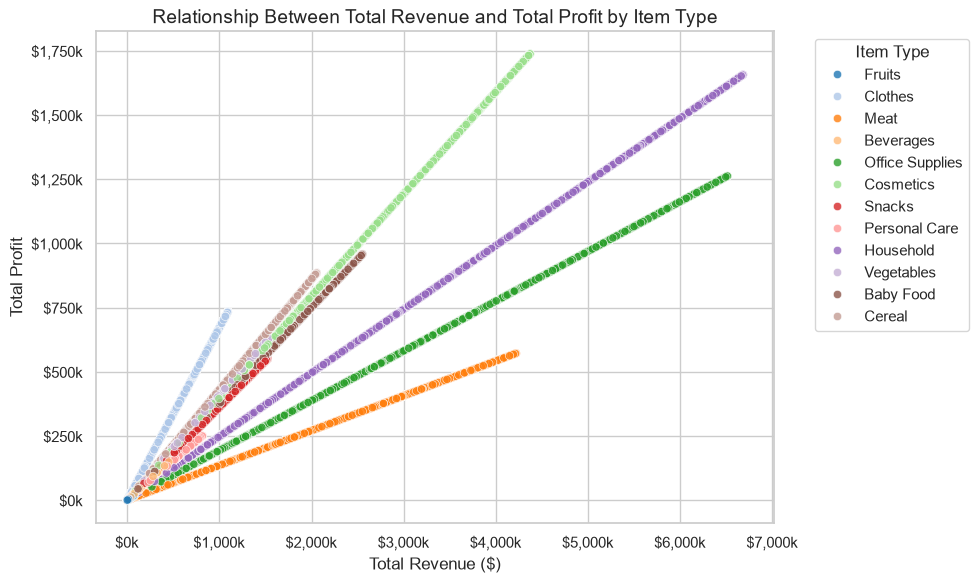

```python
from matplotlib.ticker import FuncFormatter

#spc = scatter plot column
spc1 ="Total Revenue"
spc2 ="Total Profit"
spc3 ="Item Type"

plt.figure(figsize=(10, 6))
sns.scatterplot(data=df_cleaned, x=spc1, y=spc2, hue=spc3, palette="tab20", alpha=0.8)


plt.title(f"Relationship Between {spc1} and {spc2} by {spc3}", fontsize=14)
plt.xlabel(f"{spc1} ($)")
plt.ylabel(f"{spc2}")

# Formating of the x-axis and y-axis to show currency nicely
formatter = FuncFormatter(lambda x, pos: f"${int(x/1000):,}k")
plt.gca().xaxis.set_major_formatter(formatter)
plt.gca().yaxis.set_major_formatter(formatter)

# legend is moved outside the plot area so it is clean and doesn't overlap points
plt.legend(bbox_to_anchor=(1.05, 1), loc='upper left', title=f"{spc3}")
plt.tight_layout()
plt.show()
```

**Observation:** The scatter plot displays a clear upward-sloping linear trend, showing that `Total Profit` increases predictably as `Total Revenue` increases. By coloring the points by `Item Type`, we can see that premium categories like **Cosmetics** and **Household** are responsible for the high-value transactions in the upper-right corner, while low-cost items like **Fruits** and **Beverages** cluster tightly in the bottom-left corner with low revenue and profit.

- A grouped box plot.

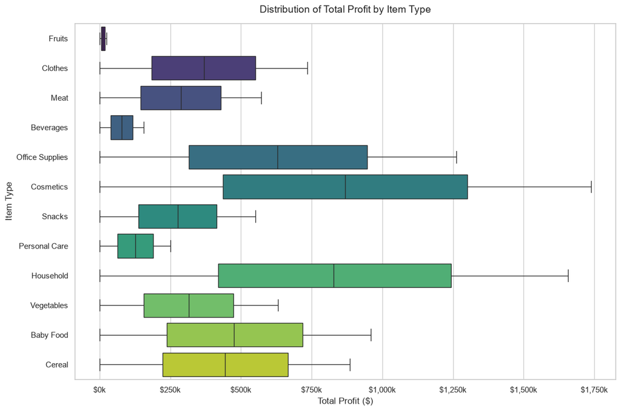

```python
plt.figure(figsize=(12, 8))

# gbpc = group box plot
gbpc1="Item Type"
gbpc2="Total Profit"
gbpc3="Item Type" # must be categorial

sns.boxplot(data=df_cleaned, y=gbpc1, x=gbpc2, hue=gbpc3, palette="viridis", legend=False)

plt.title(f"Distribution of Total Profit by {gbpc3}", fontsize=14, pad=15)
plt.ylabel(gbpc3, fontsize=12)
plt.xlabel("Total Profit ($)", fontsize=12)

# Formating of the x-axis to show currency nicely
plt.gca().xaxis.set_major_formatter(plt.FuncFormatter(lambda x, loc: f"${int(x/1000):,}k"))

plt.tight_layout()
plt.show()
```

- A table, or crosstab.

```python
#ctc= crosstab column

ctc1 = 'Region'
ctc2 = 'Sales Channel'



print(f"--- Crosstab: data count by {ctc1} and  {ctc2} ---")

# 2. Generate the crosstab
ct = pd.crosstab(df_cleaned[ctc1], df_cleaned[ctc2], margins=True, margins_name="Total")

# 3. Create the subset dynamically (all columns except 'Total')
subset_list = [c for c in ct.columns if c != "Total"]

# 4. Apply styling using the loop-generated list
styled_crosstab = ct.style.background_gradient(cmap='Blues', subset=subset_list)

display(styled_crosstab)
```

```
--- Crosstab: data count by Region and  Sales Channel ---
```

| Sales Channel Region | Offline | Online | Total |
| --- | --- | --- | --- |
| Asia | 36448 | 36510 | 72958 |
| Australia and Oceania | 20187 | 20321 | 40508 |
| Central America and the Caribbean | 27167 | 26797 | 53964 |
| Europe | 64595 | 64691 | 129286 |
| Middle East and North Africa | 31053 | 30967 | 62020 |
| North America | 5418 | 5424 | 10842 |
| Sub-Saharan Africa | 65293 | 65129 | 130422 |
| Total | 250161 | 249839 | 500000 |

**Observation:** The crosstab table shows that **Sub-Saharan Africa** and **Europe** generate the highest overall transaction counts in our dataset. More importantly, the split between **Online** and **Offline** sales channels is almost perfectly balanced (roughly 50/50) across every single global region, indicating that customer preferences for digital shopping versus physical retail are remarkably consistent worldwide.

#### 3.3 Looking at Multiple Columns Together

##### 3.3.1 Create a pair plot using at least three columns.

```
--- Generating Multi-Column Pair Plot ---
```

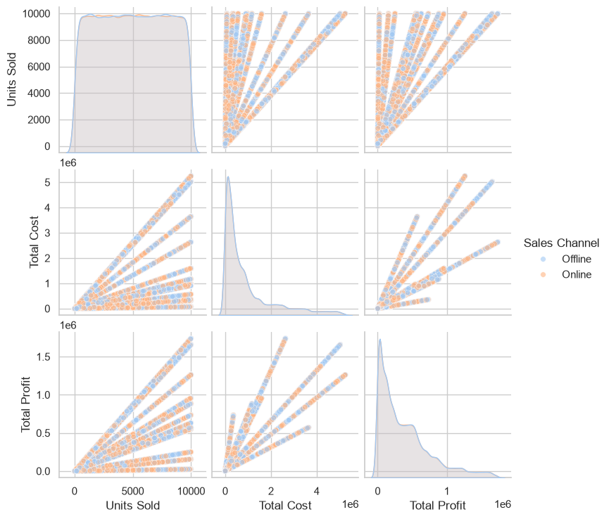

```python
# ppc = pair plot columns
ppc1 = 'Units Sold'
ppc2 = 'Total Cost'
ppc3 = 'Total Profit'
ppc4 = 'Sales Channel' #must be categorical

pairplot_features = [ppc1 , ppc2 , ppc3 , ppc4]

print("--- Generating Multi-Column Pair Plot ---")

# Generate pair plot
sns.pairplot(
    data=df_cleaned[pairplot_features],
    hue=ppc4,
    palette='pastel',
    diag_kind='kde',
    plot_kws={'alpha': 0.6, 's': 30}
)
plt.show()
```

##### 3.3.4 Explain why this insight is useful for understanding the dataset.

This multi-dimensional insight is highly useful for several reasons:

1. **Inventory Strategy:** It proves that a single sales strategy cannot be applied to all products. High-volume, low-margin products (like Fruits) require purely volume-driven logistics, while low-volume, high-margin products (like Cosmetics) require premium supply chain protection.
2. **Identical Channel Behavior:** Since the curves for **Online** and **Offline** channels overlap almost perfectly across all plots, it proves that sales channels do not change order sizes or cost structures. Business planners can safely assume identical operational behavior across both channels.

#### 3.4 Summary of Findings

##### 3.4.1 What you noticed in the single-column analysis.

- **Item Type:** Transaction frequency is exceptionally uniform across all 12 product categories (ranging closely between 41.5k and 41.8k transactions). **Personal Care** is the most frequent while **Office Supplies** is the least frequent, though the difference between them is a minor 211 transactions.

##### 3.4.2 The strongest relationship between two columns.

The strongest linear relationship in the entire dataset is between **`Total Revenue`** and **`Total Cost`**, with a near-perfect positive correlation of **`0.99`**. In real terms, this indicates that the company's expenses scale directly and predictably in proportion to its top-line sales volume.

- Furthermore, we observed that while `Total Revenue` and `Total Profit` are strongly linked, the profitability of a transaction is heavily dictated by its `Item Type`, with high-margin premium goods (Cosmetics and Household) generating far more profit per transaction than low-cost volume-driven lines (Fruits and Beverages).

##### 3.4.3 The key pattern found when looking at multiple columns together.

**The Branching Fan Pattern:** When plotting `Units Sold`, `Total Cost`, and `Total Profit` together in a pair plot, we observed that the scatter plots split into distinct diagonal "rays" or branching lines. This multi-dimensional clustering proves that product categories act as separate performance classes with completely different profit-to-cost scaling structures.

- **Symmetric Sales Channels:** Additionally, the distribution curves (KDEs) for Online and Offline transactions overlap almost perfectly, showing that customer purchasing volume and cost behavior remain identical across both sales channels.

##### 3.4.4 What these results tell you about the dataset overall.

Overall, these results tell us that this dataset represents a highly structured, stable, and predictable global wholesale business. Profitability is not driven by *where* a product is sold (Sales Channel or Region) but rather by *what* is being sold (Item Type) and *how much* is ordered (Units Sold).

- The absence of noise, errors, or significant structural imbalances makes this dataset an ideal candidate for predictive machine learning, specifically for predicting profit margins or transaction values.

### 4. Possible Machine Learning Questions

##### 4.1 Can the target variable be predicted using the most strongly correlated features?

- **Hypothetical Target Variable:** `Total Revenue` (Continuous)
- **Most Strongly Correlated Predictor Feature:** `Total Cost` (Numerical, correlation value: $0.99$)
- **Justification:** : The target variable can be predicted with extremely high accuracy using its most strongly correlated feature. Our correlation heatmap revealed a near-perfect positive linear relationship ($r = 0.99$) between `Total Revenue` and `Total Cost`. In statistical modeling, such a strong correlation suggests a highly predictive relationship. A Simple Linear Regression model trained to predict `Total Revenue` using `Total Cost` as the predictor would achieve an $R^2$ score close to $1.0$, demonstrating that top-line performance is highly predictable from operating expenses.

### 5. Final Verdict

- The dataset is **fully prepared and ready** for supervised machine learning tasks.
- **Recommendation:** Due to the massive variance scale between financial metrics (from $0 up to $1.5M+), we highly recommend applying **Feature Scaling** (such as StandardScaler or MinMaxScaler) to the numerical predictors before training distance-sensitive algorithms like K-Nearest Neighbors (KNN) or Support Vector Machines (SVM). No further cleaning or imbalance treatment is required.